# tutorial6answers

1. Reviewing the unit root test on log CPI:

   ```r
   dt <- read.csv("CPI.csv")
   Y <- ts(log(dt$CPI), start=c(1922,2), end=c(2025,2), frequency=4)
   Y <- window(Y, start=c(1946,1), end=c(2019,4))
   ```

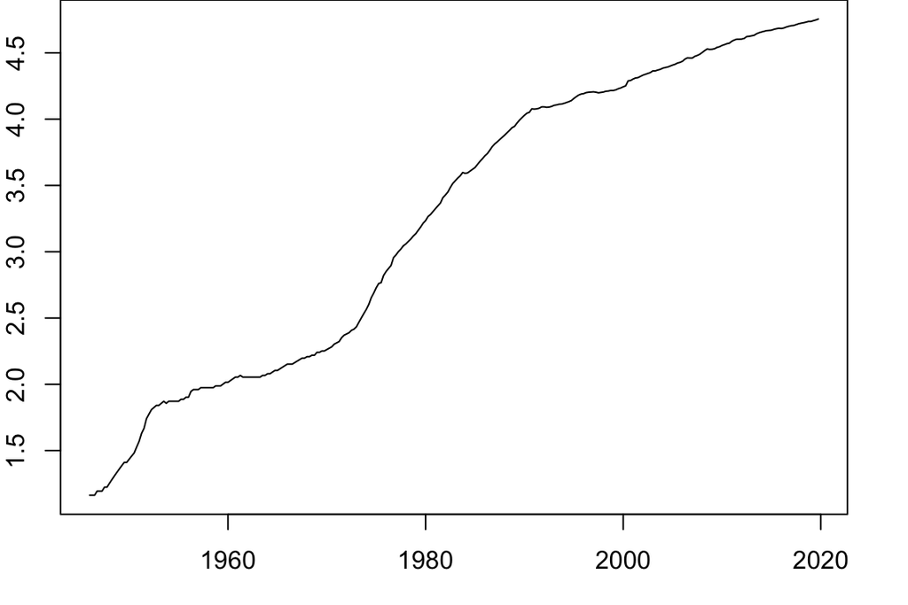

   ```r
   plot(Y)
   ```

   ```r
   library(urca)
   adf <- ur.df(Y, type="trend", selectlags="AIC")
   p_adf <- punitroot(adf@teststat[1], trend="ct", statistic="t")
   ```

   ```
   Since p_adf = 0.997 > 0.05, H0:unit root is not rejected.
   ```

   1. Differencing the log of CPI gives inflation:

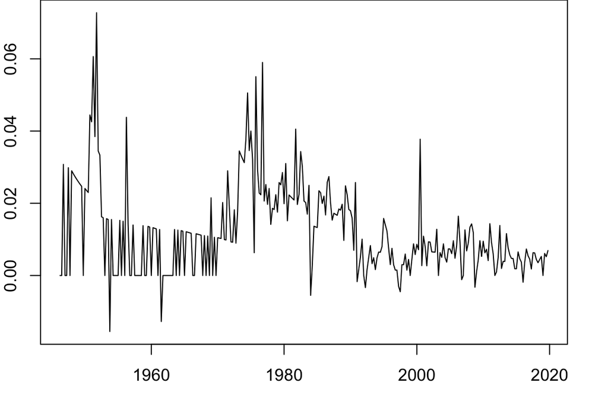

      ```r
      DY <- diff(Y)
      plot(DY)
      ```

      There is no evidence of a linear trend in this time series. There are some extended periods (early 1950’s and 1970-80’s) where inflation was higher, but these are not indicative of an overall upwards or downwards trend.
   2. Carrying out the unit root test on inflation:

      ```r
      adf <- ur.df(DY, type="drift", selectlags="AIC")
      p_adf <- punitroot(adf@teststat[1], trend="c", statistic="t")
      ```

      ```
      Since p_adf = 0.0000 < 0.05, H0:unit root is rejected.
      ```

      The conclusion is that this inflation time series can be treated as stationary, i.e. a single difference of log CPI should be taken.
   3. Code for model search:

      ```r
      library(forecast)

      pmax <- 4   # Max AR lag order
      qmax <- 4   # Max MA lag order

      # Storage for Ljung-Box p-values and AICc
      LBp <- matrix(nrow=pmax+1, ncol=qmax+1)
      rownames(LBp) <- paste0("p=", 0:pmax)
      colnames(LBp) <- paste0("q=", 0:qmax)
      AICc <- LBp

      for (p in 0:pmax){
        for (q in 0:qmax){

          eq <- Arima(DY, order=c(p, 0, q))

          LBp[p+1, q+1] <- Box.test(eq$residuals,
                                    lag = 8,
                                    type = "Ljung-Box",
                                    fitdf = p + q)$p.value

          AICc[p+1, q+1] <- eq$aicc

        }
      }
      ```

      Residual autocorrelation significant:

      ```r
      print(LBp<0.05)
      ```

      ```
           q=0  q=1   q=2   q=3   q=4
      p=0 TRUE TRUE  TRUE  TRUE  TRUE
      p=1 TRUE TRUE FALSE FALSE FALSE
      p=2 TRUE TRUE FALSE FALSE FALSE
      p=3 TRUE TRUE FALSE FALSE FALSE
      p=4 TRUE TRUE  TRUE FALSE  TRUE
      ```

      Model to minimise AICc:

      ```r
      print(AICc==min(AICc))
      ```

      ```
            q=0   q=1   q=2   q=3   q=4
      p=0 FALSE FALSE FALSE FALSE FALSE
      p=1 FALSE FALSE FALSE  TRUE FALSE
      p=2 FALSE FALSE FALSE FALSE FALSE
      p=3 FALSE FALSE FALSE FALSE FALSE
      p=4 FALSE FALSE FALSE FALSE FALSE
      ```

      The chosen model is ARMA(1, 3) for $\Delta Y_t$, equivalently ARIMA(1, 1, 3) for $Y_t$.

      Here are some equivalent ways to estimate the model. In symbols, in terms of $Y_t$ (the original log CPI time series, with linear trend), this model is:
      $$\begin{aligned}
      Y_t &= \beta_0 + \beta_1 t + Z_t \\
      \Delta Z_t &= \phi_1 \Delta Z_{t-1}
      + U_t + \theta_1 U_{t-1} + \theta_2 U_{t-2} + \theta_3 U_{t-3}
      \end{aligned}$$
      The equation for $Z_t$ shows the ARIMA(1, 1, 3) structure, and the equation for $Y_t$ includes the linear trend. The linear trend in this case is being modelled in terms of the observation index $t$, i.e. $t=1,2,3,\ldots$ (as opposed to $\text{Time}_t$ that we have used before). The implication is that $\beta_1$ measures the mean increase in $Y_t$ *per time period*, i.e. *per quarter*.

      To estimate the ARIMA(1, 0, 3) model for $\Delta Y_t$, with that difference already being taken in computing `DY` :

      ```r
      eq_a <- Arima(DY, order = c(1, 0, 3))
      print(round(eq_a$coef, 4))
      ```

      ```
            ar1       ma1       ma2       ma3 intercept
         0.8316   -0.6377    0.2380    0.1276    0.0120
      ```

      In equation form, this estimated model can be written:
      $$\begin{aligned}
      \Delta Y_t &= 0.0120 + \widehat{\Delta Z}_t \\
      \widehat{\Delta Z}_t &=
      0.8316 \widehat{\Delta Z}_{t-1}
      + \widehat{U}_t
      -0.6377 \: \widehat{U}_{t-1}
      +0.2380 \: \widehat{U}_{t-2}
      +0.1276 \: \widehat{U}_{t-3}.
      \end{aligned}$$
      The intercept of the model, $\widehat{\beta}_1 = 0.0120$, implies the estimated mean rate of inflation is 0.0120, or 1.2%, per quarter (this is a quarterly time series).

      The same model may be estimated as an ARIMA(1, 1, 3) model for $Y_t$:

      ```r
      eq_b <- Arima(Y, order = c(1, 1, 3), include.drift = TRUE)
      ```

      Note the `include.drift = TRUE` option, which is necessary for the inclusion of $\beta_1$ (called “drift” in this context where the intercept captures the linear trend) when the differencing is included in the model in this way, rather than taking the difference beforehand as we did in the first model for `DY`. The two approaches are equivalent for estimation, as can be seen from these coefficient estimates:

      ```r
      print(round(eq_b$coef, 4))
      ```

      ```
          ar1     ma1     ma2     ma3   drift
       0.8316 -0.6377  0.2380  0.1276  0.0120
      ```

      There is a difference between the two when it comes to forecasting — the first is a model for `DY` and hence will generate forecasts for $\Delta Y_t$ (inflation), while the second is model for `Y` and hence will generate forecasts for $Y_t$ (log CPI). This is demonstrated in part (e). Neither is necessarily better / worse, it just depends on the intended purpose.
   4. Before proceding to forecasting, recall that in earlier applications we have used $\text{Time}_t$ (the observation *date*) to model the linear trend, rather than $t$ (the observation *index*). These are mathematically equivalent in the sense that they both increase linearly, they differ only in scaling and relative convenience. Using the observation index is the default in time series model estimation commands and is therefore convenient and most commonly used. Using the observation date can be convenient for interpretation (i.e. if you are asked to find an estimate of the trend for the June quarter 2022, simply use $\text{Time}_t = 2022.25$, while the value of $t$ corresponding to the June quarter 2022 would need to be worked out depending on the observed sample), and also convenient for defining other variables like structural breaks (eg. to define a Covid structural break we could use break *date* $b = 2020$, but to express this in terms of observation index again requires an extra step to find which observation index corrresponds to 2020). The difference between using observation date and observation index should not be overstated — they are equivalent and most often the index is used by default.

      Examining these differences is a way to help understand the way in which these models work, and the different ways in which we might measure *time* in *time* series analysis.

      In terms of the observation *date*, consider the model representation
      $$\begin{aligned}
      Y_t &= \beta_0^* + \beta_1^* \text{Time}_t + Z_t \\
      \Delta Z_t &= \phi_1 \Delta Z_{t-1}
      + U_t + \theta_1 U_{t-1} + \theta_2 U_{t-2} + \theta_3 U_{t-3}
      \end{aligned}$$
      The connection between the observation index and observation date can be shown as follows:

      ```r
      # Sample size
      n <- length(Y)

      # Observation indices
      t <- 1:n

      # Observation dates
      Time <- time(Y)
      ```

      Here are the first and last few observation indices and dates:

      ```
              t    Time
      1946 Q1 1 1946.00
      1946 Q2 2 1946.25
      1946 Q3 3 1946.50
      1946 Q4 4 1946.75
      1947 Q1 5 1947.00
      1947 Q2 6 1947.25
      ```

      ```
                t    Time
      2018 Q3 291 2018.50
      2018 Q4 292 2018.75
      2019 Q1 293 2019.00
      2019 Q2 294 2019.25
      2019 Q3 295 2019.50
      2019 Q4 296 2019.75
      ```

      In the trend model with observation *indices*:
      $$Y_t = \beta_0 + \beta_1 t + Z_t$$
      the interpretation of $\beta_1$ is the change in mean of $Y_t$ when $t$ increases by one (i.e. when time advances by one period, one quarter in this case.). In the trend model with observation *dates*:
      $$Y_t = \beta_0^* + \beta_1^* \text{Time}_t + Z_t$$
      the interpretation of $\beta_1^*$ is the change in mean of $Y_t$ when $\text{Time}_t$ increases by one (i.e. one *year* in this case). The implication is that $\beta_1^* = 4 \beta_1$ with quarterly data.

      We generally wouldn’t need to go through this, but to show formally the relationship between the two models we start with
      $$\text{Time}_t = 1945.75 + 0.25 \: t$$
      (for this particular application and sample), so that
      $$\begin{aligned}
      Y_t &= \beta_0^* + \beta_1^* \: \text{Time}_t + Z_t \\
      &= \beta_0^* + \beta_1^* \: (1945.75 + 0.25 \: t) + Z_t \\
      &= (\beta_0^* + \beta_1^* \times 1945.75) + (\beta_1^* \times 0.25) \, t + Z_t.
      \end{aligned}$$
      Comparison with the trend model in terms of the observation indices shows that
      $$\beta_0 = \beta_0^* + \beta_1^* \times 1945.75, \quad
      \beta_1 = \beta_1^* \times 0.25,$$
      the latter relationship between $\beta_1$ and $\beta_1^*$ being consistent with $\beta_1^* = 4 \beta_1$ shown above.

      Here is how to estimate the ARIMA(1, 1, 3) model for $Y_t$ using $\text{Time}_t$ for the trend:

      ```r
      eq_c <- Arima(Y, order = c(1, 1, 3), include.drift = FALSE, xreg = Time)
      ```

      The `xreg = Time` option includes $\text{Time}_t$, which plays the role of the drift / linear trend, so `include.drift = FALSE` is added (`FALSE` is actually the default, but this is included here to emphasise the point). The coefficient estimates are shown here:

      ```r
      print(round(eq_c$coef, 4))
      ```

      ```
          ar1     ma1     ma2     ma3    xreg
       0.8317 -0.6377  0.2379  0.1275  0.0478
      ```

      Note that the AR and MA coefficient estimates are the same as those above, as expected. The `xreg` coefficient is the coefficient on `Time`. In equation form the estimated trend equation (in first differences) would be written
      $$\Delta Y_t = 0.0478 \: \Delta \text{Time}_t + \widehat{\Delta Z_t}.$$
      Noting that $\Delta \text{Time}_t = 0.25$ (for quarterly data), this becomes
      $$\Delta Y_t = 0.0120 + \widehat{\Delta Z_t},$$
      matching the estimate above.

      The point of all of this is to show that we may model the linear trend in terms of observation date or observation index, according to which is more convenient, and the resulting model will be equivalent either way.
   5. Firstly here is the one-step-ahead forecast for inflation, which is `DY`, i.e. $\Delta \log \text{CPI}_t$, from the model directly for `DY`:

      ```r
      Forecast_Inflation_2020q1 <- forecast(eq_a, h = 1)$mean
      print(round(Forecast_Inflation_2020q1, 4))
      ```

      ```
             Qtr1
      2020 0.0071
      ```

      This is the forecast for $\Delta Y_{n+1}$. To calculate the forecast for $Y_{n+1}$ (which is $\log \text{CPI}_{n+1}$), we could use the identity
      $$Y_{n+1} = Y_{n} + \Delta Y_{n+1}.$$
      On both sides take $\widehat{E}(\, \cdot \: | \: {\mathscr{Y}}_{n} \, )$ (i.e. the forecast based on data up to the end of the sample, $t=n$):
      $$\widehat{E}(\, Y_{n+1} \: | \: {\mathscr{Y}}_{n} \, )
      = Y_{n} + \widehat{E}( \, \Delta Y_{n+1} \: | \: {\mathscr{Y}}_{n} \, ),$$
      noting that $\widehat{E}(\, Y_{n} \: | \: {\mathscr{Y}}_{n} \, ) = Y_n$ because $Y_n$ is included in ${\mathscr{Y}}_{n}$. We have computed
      $$\widehat{E}( \, \Delta Y_{n+1} \: | \: {\mathscr{Y}}_{n} \, ) =
      0.0071,$$
      and the last value in the sample is
      $$Y_n = \texttt{Y[n]} = 4.7553128.$$
      Thus
      $$\widehat{E}(\, Y_{n+1} \: | \: {\mathscr{Y}}_{n} \, )
      = 4.7553128 + 0.0071
      = 4.7624.$$
      Note this is the forecast for $\log \text{CPI}_{n+1}$.

      As an alternative, if we were only concerned with forecasting $\log \text{CPI}_{n+1}$ and not the inflation rate, we could use the model for `Y`. This directly forecasts `Y`, rather than forecasting `DY` and then computing the forecast for `Y` from that.

      ```r
      Forecast_logCPI_2020q1 <- forecast(eq_b, h = 1)$mean
      print(round(Forecast_logCPI_2020q1, 4))
      ```

      ```
             Qtr1
      2020 4.7624
      ```

      ```r
      Forecast_logCPI_2020q1_c <- forecast(eq_c, xreg = 2020.00)$mean
      print(round(Forecast_logCPI_2020q1_c, 4))
      ```

      ```
             Qtr1
      2020 4.7624
      ```

      Now let’s calculate the forecast for the CPI. A simple way is to apply the inflation forecast for 2020q1 to the observed value of the CPI for 2019q4:

      ```r
      # Create a ts of CPI (i.e. not log CPI)
      CPI <- ts(dt$CPI, start=c(1922,2), end=c(2025,2), frequency=4)

      # CPI in 2019q4, last date of the estimation sample
      CPI_2019q4 <- CPI[which(time(CPI)==2019.75)]

      # Forecast CPI for 2020q1 is CPI in 2019q4 increased by
      # forecast inflation for 2020q1
      Forecast_CPI_2020q1_a <- CPI_2019q4*(1+Forecast_Inflation_2020q1)
      print(Forecast_CPI_2020q1_a)
      ```

      ```
               Qtr1
      2020 117.0254
      ```

      Another approach that will give a very similar answer is to use the forecast of $\log \text{CPI}_{n+1}$ and take the exponential to “reverse” the log transformation:

      ```r
      Forecast_CPI_2020q1_b <- exp(Forecast_logCPI_2020q1)
      print(Forecast_CPI_2020q1_b)
      ```

      ```
               Qtr1
      2020 117.0284
      ```

      Note this differs in the third decimal place to the previous approach. Neither is literally “correct”: both are approximations that, for practical purposes, are essentially equivalent (at least when inflation rates are not too high).

      *Digression*. Consider the step where we first calculate the forecast for $Y_{n+1}=\log\text{CPI}_{n+1}$ and then take the exponential to convert this into a forecast for $\text{CPI}_{n+1}$. This is very common practice and superficially seems watertight, but it turns out the resulting forecast is not a conditional expectation. In particular we have the forecast for $Y_{n+1}$ being
      $$E(Y_{n+1}|{\mathscr{Y}}_{n})
      = E(\log \text{CPI}_{n+1}|{\mathscr{Y}}_{n})$$
      Taking the exponential:
      $$\begin{align}
      \exp\left(E(Y_{n+1}|{\mathscr{Y}}_{n})\right)
      &= \exp E(\log \text{CPI}_{n+1}|{\mathscr{Y}}_{n}) \\
      &\:{\color{red}{\neq}} \:
      E(\exp \log \text{CPI}_{n+1}|{\mathscr{Y}}_{n}) \\
      &= E(\text{CPI}_{n+1}|{\mathscr{Y}}_{n})
      \end{align}$$
      The ${\color{red}{\neq}}$ step occurs because the nonlinear $\exp(.)$ operation does not pass through the linear expectation operation. If we have (an estimate of) the conditional expectation of $\log\text{CPI}_{n+1}$ we do not strictly speaking obtain the conditional expectation of $\text{CPI}_{n+1}$ by taking the exponential. To find $E(\text{CPI}_{n+1}|{\mathscr{Y}}_{n})$ from $E(\log \text{CPI}_{n+1}|{\mathscr{Y}}_{n})$ would require a more complicated calculation that would involve assumptions and/or estimates of the entire distribution of the CPI variable, not just the conditional mean. Luckily, in practice simply taking the exponential tends to work well in providing a good approximation. In fact [research suggests](https://www.sciencedirect.com/science/article/abs/pii/S0169207011000112) it tends to work better in practice than the theoretically correct formula. So we will continue to take exponentials whenever required.
2. Start with the autoregressive equation and re-arrange as follows:
   $$\begin{aligned}
   Z_t \quad &= \qquad \phi_1 Z_{t-1} + \phi_2 Z_{t-2} + U_t \\
   Z_t \quad &= \qquad \phi_1 Z_{t-1} {\color{magenta}{ \: + \: \phi_2 Z_{t-1} - \phi_2 Z_{t-1}}} + \phi_2 Z_{t-2} + U_t \\
   Z_t \quad &= \qquad {\color{blue}{\phi_1 Z_{t-1} + \phi_2 Z_{t-1}}}
   {\color{green}{ \: - \: \phi_2 Z_{t-1} + \phi_2 Z_{t-2}}} + U_t \\
   Z_t \quad &= \qquad\quad {\color{blue}{(\phi_1 + \phi_2) Z_{t-1}}}
   \quad {\color{green}{\: - \: \phi_2 \Delta Z_{t-1}}} + U_t \\
   Z_t {\color{red}{ \: - \: Z_{t-1}}} &=
   {\color{red}{-Z_{t-1}}} + (\phi_1 + \phi_2) Z_{t-1}
   - \phi_2 \Delta Z_{t-1} + U_t \\
   \hskip 2cm \Delta Z_t &= \varphi Z_{t-1} + \psi_1 \Delta Z_{t-1} + U_t \hskip 6cm (1)
   \end{aligned}$$
   where $\varphi = \phi_1 + \phi_2 - 1$ and $\psi_1 = - \phi_2$.

   Now consider the trend equation
   $$Y_t = \beta_0 + \beta_1 t + Z_t$$
   and take the first difference:
   $$\hskip 5cm
   \Delta Y_t = \Delta \beta_0 + \beta_1 \Delta t + \Delta Z_t.
   \hskip 4cm (2)$$
   In this equation:
   $$\Delta \beta_0 = 0$$
   since the intercept is by definition constant over time (i.e. does not change from one period to the next), and
   $$\Delta t = t - (t-1) = 1.$$
   Substitution of $\Delta \beta_0 = 0$ and $\Delta t = 1$ into equation (2) gives
   $$\hskip 6cm
   {\color{red}{\Delta Z_t = \Delta Y_t - \beta_1.}}
   \hskip 5cm (3)$$
   A lag of this equation is
   $$\hskip 6cm
   {\color{magenta}{\Delta Z_{t-1} = \Delta Y_{t-1} - \beta_1.}}
   \hskip 4.5cm (4)$$
   A lag of the original trend equation can be written
   $$\hskip 5cm
   {\color{blue}{Z_{t-1} = Y_{t-1} - \beta_0 - \beta_1 (t-1)}}
   \hskip 4cm (5)$$

   Substitution of (3), (4) and (5) into (1) gives
   $$( \: {\color{red}{\Delta Y_t - \beta_1}} \: ) =
   \varphi ( \: {\color{blue}{Y_{t-1} - \beta_0 - \beta_1 (t-1)}} \: )
   + \psi_1 ( \: {\color{magenta}{\Delta Y_{t-1} - \beta_1}} \: )
   + U_t$$
   Rearranging gives:
   $$\begin{aligned}
   \Delta Y_t &= \varphi \, Y_{t-1}
   + (\: {\color{green}{\beta_1 - \varphi \beta_0 + \varphi \beta_1 - \psi_1 \beta_1}} \:)
   {\color{orange}{\: - \: \varphi \beta_1}} \, t + \psi_1 \, \Delta Y_{t-1} + U_t \\
   \Delta Y_t &= \varphi \, Y_{t-1} \quad + \qquad {\color{green}{\beta_0^*}} \hskip 3.5cm
   + {\color{orange}{\beta_1^*}} \, t + \psi_1 \Delta Y_{t-1} + U_t
   \end{aligned}$$
   which is the ADF test equation including intercept, linear trend, and a single lagged difference, with
   $$\begin{aligned}
   {\color{green}{\beta_0^*}} &=
   {\color{green}{\beta_1 - \varphi \beta_0 + \varphi \beta_1 - \psi_1 \beta_1}} \\
   {\color{orange}{\beta_1^*}} &= {\color{orange}{- \varphi \beta_1}}
   \end{aligned}$$

   This derivation is intended to show how the ADF test equation follows from a time series model, including how the lag length is reduced by one and how the deterministic coefficients differ between the trend equation and ADF test equation. Having seen this once, the details become practically unimportant thereafter — the values of the deterministic coefficients in the ADF test regression are not directly interesting in themselves. The important thing is the specification of an appropriate ADF test equation from a time series model if it has already been specified.